# Fit CT-VAR Using dynr

Author

Ivan Jacob Agaloos Pesigan

Published

February 2, 2026

## Installing Required Packages

Before proceeding, ensure that the necessary packages are installed and loaded. We use `dynr` for model fitting, `expm` for matrix exponentiation, and `simStateSpace` for data generation.

```r
library(dynr)
library(expm)
library(simStateSpace)
```

## Data Generation

We simulate continuous-time data from a three-variable system ($X$, $M$, $Y$) following an Ornstein–Uhlenbeck (OU) process, which underlies the CT-VAR model.

Each latent variable evolves continuously over time according to a system of stochastic differential equations characterized by:

- Drift matrix $\boldsymbol{\Phi}$ (system dynamics),
- Process noise covariance $\boldsymbol{\Sigma}$ (process variability), and
- Measurement noise covariance $\boldsymbol{\Theta}$ (observation error)

## Data Simulation Using `simStateSpace`

We generate data using the `SimSSMOUFixed()` function from the `simStateSpace` package, which simulates trajectories from a continuous-time state-space model with fixed parameters.

```r
n
```

```
[1] 20
```

```r
time
```

```
[1] 100
```

```r
delta_t
```

```
[1] 0.1
```

```r
mu0
```

```
[1] 0 0 0
```

```r
sigma0
```

```
     [,1] [,2] [,3]
[1,]  1.0  0.2  0.2
[2,]  0.2  1.0  0.2
[3,]  0.2  0.2  1.0
```

```r
sigma0_l # sigma0_l <- t(chol(sigma0))
```

```
     [,1]      [,2]      [,3]
[1,]  1.0 0.0000000 0.0000000
[2,]  0.2 0.9797959 0.0000000
[3,]  0.2 0.1632993 0.9660918
```

```r
mu
```

```
[1] 0 0 0
```

```r
phi
```

```
       [,1]   [,2]   [,3]
[1,] -0.357  0.000  0.000
[2,]  0.771 -0.511  0.000
[3,] -0.450  0.729 -0.693
```

```r
sigma
```

```
            [,1]       [,2]        [,3]
[1,]  0.24455556 0.02201587 -0.05004762
[2,]  0.02201587 0.07067800  0.01539456
[3,] -0.05004762 0.01539456  0.07553061
```

```r
sigma_l # sigma_l <- t(chol(sigma))
```

```
            [,1]      [,2]     [,3]
[1,]  0.49452559 0.0000000 0.000000
[2,]  0.04451917 0.2620993 0.000000
[3,] -0.10120330 0.0759256 0.243975
```

```r
nu
```

```
[1] 0 0 0
```

```r
lambda
```

```
     [,1] [,2] [,3]
[1,]    1    0    0
[2,]    0    1    0
[3,]    0    0    1
```

```r
theta
```

```
     [,1] [,2] [,3]
[1,]  0.2  0.0  0.0
[2,]  0.0  0.2  0.0
[3,]  0.0  0.0  0.2
```

```r
theta_l # theta_l <- t(chol(theta))
```

```
          [,1]      [,2]      [,3]
[1,] 0.4472136 0.0000000 0.0000000
[2,] 0.0000000 0.4472136 0.0000000
[3,] 0.0000000 0.0000000 0.4472136
```

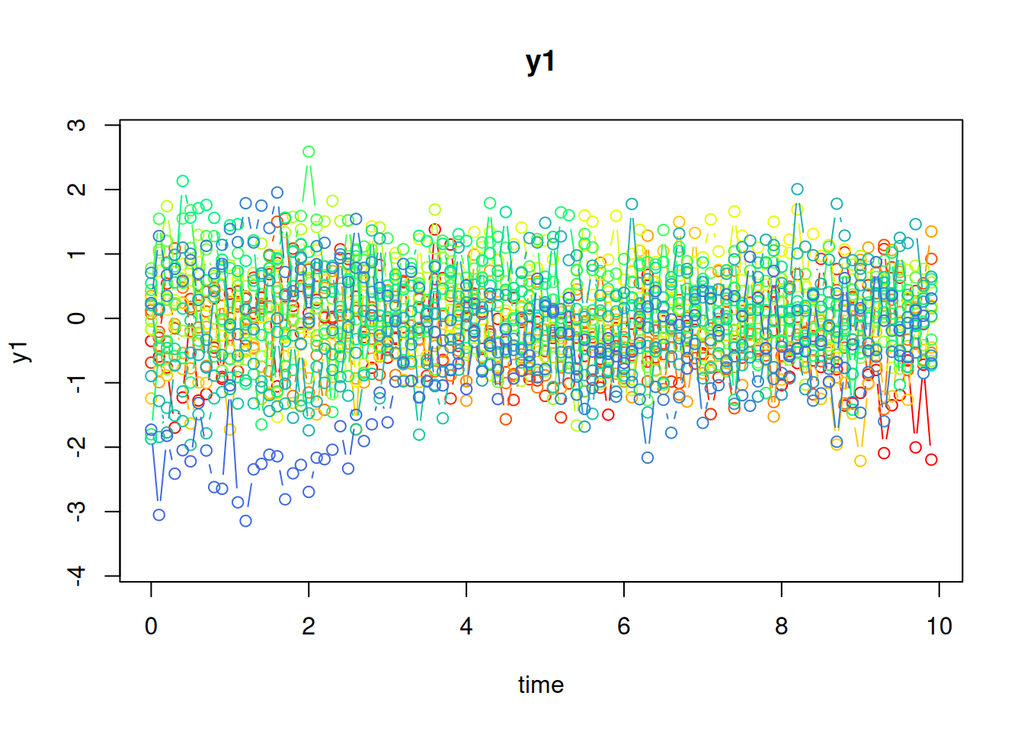

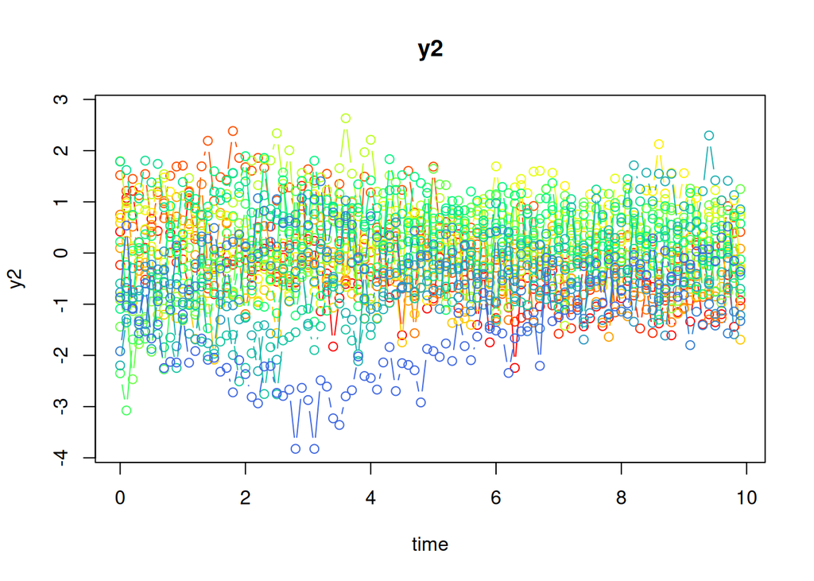

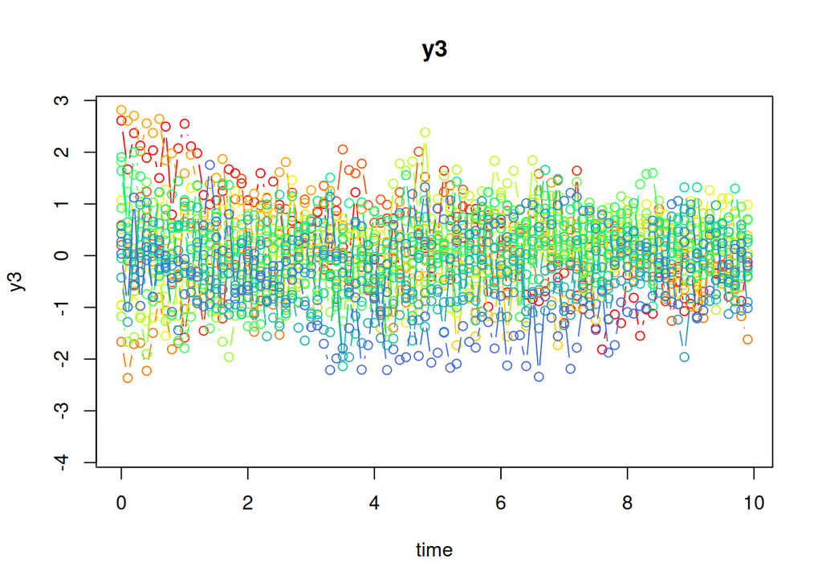

```r
sim <- SimSSMOUFixed(
  n = n,
  time = time,
  delta_t = delta_t,
  mu0 = mu0,
  sigma0_l = sigma0_l,
  mu = mu,
  phi = phi,
  sigma_l = sigma_l,
  nu = nu,
  lambda = lambda,
  theta_l = theta_l,
  type = 0
)
plot(sim)
```

```r
data <- as.data.frame(sim)
colnames(data) <- c("id", "time", "x", "m", "y")
head(data)
```

```
  id time          x          m        y
1  1  0.0 -0.3504435 0.41877429 2.611996
2  1  0.1 -0.5920330 1.07433208 1.669272
3  1  0.2 -0.7619855 1.21483834 2.369837
4  1  0.3 -1.6964652 0.21209722 2.128531
5  1  0.4 -1.2282686 0.09950326 1.891140
6  1  0.5  0.1433985 0.66784226 2.036033
```

## Fitting the CT-VAR Model Using `dynr`

We now use the `dynr` package to estimate the parameters of the CT-VAR model from the simulated data.

### Prepare the Data

```r
dynr_data <- dynr.data(
  dataframe = data,
  id = "id",
  time = "time",
  observed = c("x", "m", "y")
)
```

### Prepare the Initial Condition

```r
dynr_initial <- prep.initial(
  values.inistate = c(
    0, 0, 0
  ),
  params.inistate = c(
    "mu0_1_1", "mu0_2_1", "mu0_3_1"
  ),
  values.inicov = matrix(
    data = c(
      1.0, 0.2, 0.2,
      0.2, 1.0, 0.2,
      0.2, 0.2, 1.0
    ),
    nrow = 3
  ),
  params.inicov = matrix(
    data = c(
      "sigma0_1_1", "sigma0_2_1", "sigma0_3_1",
      "sigma0_2_1", "sigma0_2_2", "sigma0_3_2",
      "sigma0_3_1", "sigma0_3_2", "sigma0_3_3"
    ),
    nrow = 3
  )
)
```

### Prepare the Measurement Model

```r
dynr_measurement <- prep.measurement(
  values.load = diag(3),
  params.load = matrix(
    data = "fixed",
    nrow = 3,
    ncol = 3
  ),
  state.names = c("eta_x", "eta_m", "eta_y"),
  obs.names = c("x", "m", "y")
)
```

### Prepare the Dynamic Model

```r
dynr_dynamics <- prep.formulaDynamics(
  formula = list(
    eta_x ~ phi_1_1 * eta_x + phi_1_2 * eta_m + phi_1_3 * eta_y,
    eta_m ~ phi_2_1 * eta_x + phi_2_2 * eta_m + phi_2_3 * eta_y,
    eta_y ~ phi_3_1 * eta_x + phi_3_2 * eta_m + phi_3_3 * eta_y
  ),
  startval = c(
    phi_1_1 = -0.2, phi_2_1 = 0.0, phi_3_1 = 0.0,
    phi_1_2 = 0.0, phi_2_2 = -0.2, phi_3_2 = 0.0,
    phi_1_3 = 0.0, phi_2_3 = 0.0, phi_3_3 = -0.2
  ),
  isContinuousTime = TRUE
)
```

### Prepare the Noise Matrices

```r
dynr_noise <- prep.noise(
  values.latent = matrix(
    data = 0.2 * diag(3),
    nrow = 3
  ),
  params.latent = matrix(
    data = c(
      "sigma_1_1", "sigma_2_1", "sigma_3_1",
      "sigma_2_1", "sigma_2_2", "sigma_3_2",
      "sigma_3_1", "sigma_3_2", "sigma_3_3"
    ),
    nrow = 3
  ),
  values.observed = 0.2 * diag(3),
  params.observed = matrix(
    data = c(
      "theta_1_1", "fixed", "fixed",
      "fixed", "theta_2_2", "fixed",
      "fixed", "fixed", "theta_3_3"
    ),
    nrow = 3
  )
)
```

### Prepare the Model

In this example, we increase the maximum evaluations in the optimization process and constrain the lower and upper bounds of the parameters for the drift matrix.

```r
dynr_model <- dynr.model(
  data = dynr_data,
  initial = dynr_initial,
  measurement = dynr_measurement,
  dynamics = dynr_dynamics,
  noise = dynr_noise,
  outfile = "fit-ct-var-dynr.c"
)
dynr_model@options$maxeval <- 100000
lb <- ub <- rep(NA, times = length(dynr_model$xstart))
names(ub) <- names(lb) <- names(dynr_model$xstart)
lb[
  c(
    "phi_1_1", "phi_2_1", "phi_3_1",
    "phi_1_2", "phi_2_2", "phi_3_2",
    "phi_1_3", "phi_2_3", "phi_3_3"
  )
] <- -1.5
ub[
  c(
    "phi_1_1", "phi_2_1", "phi_3_1",
    "phi_1_2", "phi_2_2", "phi_3_2",
    "phi_1_3", "phi_2_3", "phi_3_3"
  )
] <- 1.5
dynr_model$lb <- lb
dynr_model$ub <- ub
```

### Model Estimation

We estimate the parameters using `dynr.cook()`.

```r
fn <- "fit-ct-var-dynr.Rds"
if (file.exists(fn)) {
  fit <- readRDS(fn)
} else {
  fit <- dynr.cook(
    dynr_model,
    verbose = FALSE
  )
  saveRDS(fit, file = fn)
}
```

```
[1] "Get ready!!!!"
using C compiler: ‘gcc (Ubuntu 13.3.0-6ubuntu2~24.04) 13.3.0’
Optimization function called.
Starting Hessian calculation ...
Finished Hessian calculation.
Original exit flag:  3
Modified exit flag:  3
Optimization terminated successfully: ftol_rel or ftol_abs was reached.
Original fitted parameters:  -0.2150421 0.7992531 -0.5372629 -0.1590345
-0.527781 0.7714035 0.09440367 0.0700308 -0.7375808 -1.531834 0.06888895
-0.2670268 -2.826667 0.1710893 -2.686909 -1.630224 -1.604964 -1.643162
-0.1764606 -0.2433819 0.331227 -0.3120474 -0.1145515 0.140546 0.1462391
0.01082431 0.268019

Transformed fitted parameters:  -0.2150421 0.7992531 -0.5372629 -0.1590345
-0.527781 0.7714035 0.09440367 0.0700308 -0.7375808 0.2161389 0.01488958
-0.05771489 0.06023562 0.006154261 0.08523567 0.1958856 0.2008968 0.1933677
-0.1764606 -0.2433819 0.331227 0.7319468 -0.08384563 0.1028722 1.167078
0.0007446744 1.321966

Doing end processing
Successful trial
Total Time: 2.488782
Backend Time: 2.470807
```

```r
summary(fit)
```

```
Coefficients:
             Estimate Std. Error t value   ci.lower   ci.upper Pr(>|t|)
phi_1_1    -0.2150421  0.1195297  -1.799 -0.4493160  0.0192318   0.0361 *
phi_2_1     0.7992531  0.0799146  10.001  0.6426233  0.9558830   <2e-16 ***
phi_3_1    -0.5372629  0.0900443  -5.967 -0.7137466 -0.3607793   <2e-16 ***
phi_1_2    -0.1590345  0.0980611  -1.622 -0.3512306  0.0331617   0.0525 .
phi_2_2    -0.5277810  0.0669206  -7.887 -0.6589430 -0.3966190   <2e-16 ***
phi_3_2     0.7714035  0.0748155  10.311  0.6247679  0.9180392   <2e-16 ***
phi_1_3     0.0944037  0.0879781   1.073 -0.0780302  0.2668375   0.1417
phi_2_3     0.0700308  0.0592130   1.183 -0.0460246  0.1860862   0.1185
phi_3_3    -0.7375808  0.0671581 -10.983 -0.8692084 -0.6059533   <2e-16 ***
sigma_1_1   0.2161389  0.0333941   6.472  0.1506876  0.2815902   <2e-16 ***
sigma_2_1   0.0148896  0.0142932   1.042 -0.0131246  0.0429038   0.1488
sigma_3_1  -0.0577149  0.0166399  -3.468 -0.0903285 -0.0251013   0.0003 ***
sigma_2_2   0.0602356  0.0123083   4.894  0.0361118  0.0843594   <2e-16 ***
sigma_3_2   0.0061543  0.0098537   0.625 -0.0131586  0.0254671   0.2662
sigma_3_3   0.0852357  0.0167118   5.100  0.0524810  0.1179903   <2e-16 ***
theta_1_1   0.1958856  0.0078438  24.973  0.1805121  0.2112592   <2e-16 ***
theta_2_2   0.2008968  0.0070651  28.435  0.1870494  0.2147442   <2e-16 ***
theta_3_3   0.1933677  0.0070266  27.519  0.1795958  0.2071396   <2e-16 ***
mu0_1_1    -0.1764606  0.1990029  -0.887 -0.5664990  0.2135778   0.1877
mu0_2_1    -0.2433819  0.2454784  -0.991 -0.7245107  0.2377469   0.1608
mu0_3_1     0.3312270  0.2619670   1.264 -0.1822190  0.8446729   0.1031
sigma0_1_1  0.7319468  0.2506898   2.920  0.2406039  1.2232897   0.0018 **
sigma0_2_1 -0.0838456  0.2213391  -0.379 -0.5176622  0.3499710   0.3524
sigma0_3_1  0.1028722  0.2350566   0.438 -0.3578302  0.5635746   0.3308
sigma0_2_2  1.1670776  0.3852839   3.029  0.4119350  1.9222202   0.0012 **
sigma0_3_2  0.0007447  0.2904693   0.003 -0.5685648  0.5700541   0.4990
sigma0_3_3  1.3219659  0.4366714   3.027  0.4661057  2.1778261   0.0012 **
---
Signif. codes:  0 '***' 0.001 '**' 0.01 '*' 0.05 '.' 0.1 ' ' 1

-2 log-likelihood value at convergence = 8608.96
AIC = 8662.96
BIC = 8814.18
```

### Extracting Matrices for Use in `cTMed`

After fitting, we extract the estimated drift matrix ($\boldsymbol{\Phi}$) and process noise covariance ($\boldsymbol{\Sigma}$), along with their sampling covariance matrices.

```r
coefs <- coef(fit)
vcovs <- vcov(fit)
phi_names <- c(
  "phi_1_1", "phi_2_1", "phi_3_1",
  "phi_1_2", "phi_2_2", "phi_3_2",
  "phi_1_3", "phi_2_3", "phi_3_3"
)
sigma_names <- c(
  "sigma_1_1", "sigma_2_1", "sigma_3_1",
  "sigma_2_1", "sigma_2_2", "sigma_3_2",
  "sigma_3_1", "sigma_3_2", "sigma_3_3"
)
sigma_vech_names <- c(
  "sigma_1_1", "sigma_2_1", "sigma_3_1",
  "sigma_2_2", "sigma_3_2",
  "sigma_3_3"
)
theta_names <- c(
  "phi_1_1", "phi_2_1", "phi_3_1",
  "phi_1_2", "phi_2_2", "phi_3_2",
  "phi_1_3", "phi_2_3", "phi_3_3",
  "sigma_1_1", "sigma_2_1", "sigma_3_1",
  "sigma_2_2", "sigma_3_2",
  "sigma_3_3"
)
phi <- matrix(
  data = coefs[phi_names],
  nrow = 3,
  ncol = 3
)
colnames(phi) <- rownames(phi) <- c("x", "m", "y")
sigma <- matrix(
  data = coefs[sigma_names],
  nrow = 3,
  ncol = 3
)
theta <- coefs[theta_names]
vcov_phi_vec <- vcovs[phi_names, phi_names]
vcov_sigma_vech <- vcovs[sigma_vech_names, sigma_vech_names]
vcov_theta <- vcovs[theta_names, theta_names]
```

#### Estimated Drift Matrix with Corresponding Sampling Covariance Matrix

```r
phi
```

```
           x          m           y
x -0.2150421 -0.1590345  0.09440367
m  0.7992531 -0.5277810  0.07003080
y -0.5372629  0.7714035 -0.73758084
```

```r
vcov_phi_vec
```

```
              phi_1_1       phi_2_1       phi_3_1       phi_1_2       phi_2_2
phi_1_1  0.0142873522  0.0006079799 -0.0030038849 -0.0097797943 -4.790491e-04
phi_2_1  0.0006079799  0.0063863490 -0.0004996187 -0.0001104026 -4.577211e-03
phi_3_1 -0.0030038849 -0.0004996187  0.0081079793  0.0018766011  4.121789e-04
phi_1_2 -0.0097797943 -0.0001104026  0.0018766011  0.0096159753  2.870124e-04
phi_2_2 -0.0004790491 -0.0045772109  0.0004121789  0.0002870124  4.478369e-03
phi_3_2  0.0020607367  0.0002166850 -0.0056919613 -0.0020116829 -3.373929e-04
phi_1_3  0.0066272153 -0.0000384865 -0.0010966857 -0.0065404706 -5.471564e-05
phi_2_3  0.0003941462  0.0031845277 -0.0003412820 -0.0003010944 -3.150796e-03
phi_3_3 -0.0014572097 -0.0001184132  0.0039009020  0.0014237474  1.646252e-04
              phi_3_2       phi_1_3       phi_2_3       phi_3_3
phi_1_1  0.0020607367  6.627215e-03  0.0003941462 -0.0014572097
phi_2_1  0.0002166850 -3.848650e-05  0.0031845277 -0.0001184132
phi_3_1 -0.0056919613 -1.096686e-03 -0.0003412820  0.0039009020
phi_1_2 -0.0020116829 -6.540471e-03 -0.0003010944  0.0014237474
phi_2_2 -0.0003373929 -5.471564e-05 -0.0031507962  0.0001646252
phi_3_2  0.0055973556  1.189036e-03  0.0003301834 -0.0038753551
phi_1_3  0.0011890355  7.740141e-03  0.0002868850 -0.0016934695
phi_2_3  0.0003301834  2.868850e-04  0.0035061835 -0.0003437688
phi_3_3 -0.0038753551 -1.693470e-03 -0.0003437688  0.0045102156
```

#### Process Noise Covariance Matrix with Corresponding Sampling Covariance Matrix

```r
sigma
```

```
            [,1]        [,2]         [,3]
[1,]  0.21613889 0.014889581 -0.057714887
[2,]  0.01488958 0.060235625  0.006154261
[3,] -0.05771489 0.006154261  0.085235668
```

```r
vcov_sigma_vech
```

```
              sigma_1_1     sigma_2_1     sigma_3_1     sigma_2_2     sigma_3_2
sigma_1_1  1.115167e-03  4.004670e-05 -1.981839e-04  1.254314e-05 -1.364776e-05
sigma_2_1  4.004670e-05  2.042965e-04 -1.184950e-05  1.534016e-05 -4.509985e-05
sigma_3_1 -1.981839e-04 -1.184950e-05  2.768867e-04 -4.248350e-06  1.226255e-05
sigma_2_2  1.254314e-05  1.534016e-05 -4.248350e-06  1.514936e-04 -8.509441e-06
sigma_3_2 -1.364776e-05 -4.509985e-05  1.226255e-05 -8.509441e-06  9.709484e-05
sigma_3_3  3.967862e-05  7.242787e-06 -1.124499e-04  5.840479e-07 -1.087946e-05
              sigma_3_3
sigma_1_1  3.967862e-05
sigma_2_1  7.242787e-06
sigma_3_1 -1.124499e-04
sigma_2_2  5.840479e-07
sigma_3_2 -1.087946e-05
sigma_3_3  2.792858e-04
```

#### Estimated Drift Matrix and Process Noise Covariance Matrix with Corresponding Sampling Covariance Matrix

```r
theta
```

```
     phi_1_1      phi_2_1      phi_3_1      phi_1_2      phi_2_2      phi_3_2
-0.215042116  0.799253150 -0.537262944 -0.159034458 -0.527781028  0.771403519
     phi_1_3      phi_2_3      phi_3_3    sigma_1_1    sigma_2_1    sigma_3_1
 0.094403674  0.070030797 -0.737580843  0.216138890  0.014889581 -0.057714887
   sigma_2_2    sigma_3_2    sigma_3_3
 0.060235625  0.006154261  0.085235668
```

```r
vcov_theta
```

```
                phi_1_1       phi_2_1       phi_3_1       phi_1_2       phi_2_2
phi_1_1    1.428735e-02  6.079799e-04 -3.003885e-03 -9.779794e-03 -4.790491e-04
phi_2_1    6.079799e-04  6.386349e-03 -4.996187e-04 -1.104026e-04 -4.577211e-03
phi_3_1   -3.003885e-03 -4.996187e-04  8.107979e-03  1.876601e-03  4.121789e-04
phi_1_2   -9.779794e-03 -1.104026e-04  1.876601e-03  9.615975e-03  2.870124e-04
phi_2_2   -4.790491e-04 -4.577211e-03  4.121789e-04  2.870124e-04  4.478369e-03
phi_3_2    2.060737e-03  2.166850e-04 -5.691961e-03 -2.011683e-03 -3.373929e-04
phi_1_3    6.627215e-03 -3.848650e-05 -1.096686e-03 -6.540471e-03 -5.471564e-05
phi_2_3    3.941462e-04  3.184528e-03 -3.412820e-04 -3.010944e-04 -3.150796e-03
phi_3_3   -1.457210e-03 -1.184132e-04  3.900902e-03  1.423747e-03  1.646252e-04
sigma_1_1 -2.333538e-03 -3.147503e-04  5.590589e-04  1.229505e-03  1.558647e-04
sigma_2_1  1.860527e-04 -4.867247e-04 -7.184730e-05 -2.533846e-04  2.364259e-04
sigma_3_1  2.316315e-04  7.797280e-05 -6.592973e-04 -3.085935e-05 -2.232206e-05
sigma_2_2 -3.241493e-05  1.690887e-04  3.090526e-05  2.853755e-05 -2.312286e-04
sigma_3_2 -5.186949e-06  3.832628e-05  9.180382e-05  2.027968e-05  3.420616e-05
sigma_3_3 -3.757908e-05 -4.591419e-05  8.377694e-05 -7.921819e-07  1.697090e-05
                phi_3_2       phi_1_3       phi_2_3       phi_3_3     sigma_1_1
phi_1_1    2.060737e-03  6.627215e-03  3.941462e-04 -1.457210e-03 -2.333538e-03
phi_2_1    2.166850e-04 -3.848650e-05  3.184528e-03 -1.184132e-04 -3.147503e-04
phi_3_1   -5.691961e-03 -1.096686e-03 -3.412820e-04  3.900902e-03  5.590589e-04
phi_1_2   -2.011683e-03 -6.540471e-03 -3.010944e-04  1.423747e-03  1.229505e-03
phi_2_2   -3.373929e-04 -5.471564e-05 -3.150796e-03  1.646252e-04  1.558647e-04
phi_3_2    5.597356e-03  1.189036e-03  3.301834e-04 -3.875355e-03 -2.910012e-04
phi_1_3    1.189036e-03  7.740141e-03  2.868850e-04 -1.693470e-03 -5.863538e-04
phi_2_3    3.301834e-04  2.868850e-04  3.506184e-03 -3.437688e-04 -7.760723e-05
phi_3_3   -3.875355e-03 -1.693470e-03 -3.437688e-04  4.510216e-03  1.448105e-04
sigma_1_1 -2.910012e-04 -5.863538e-04 -7.760723e-05  1.448105e-04  1.115167e-03
sigma_2_1  7.670478e-05  1.414938e-04 -1.119311e-04 -3.768986e-05  4.004670e-05
sigma_3_1  3.251735e-04 -1.831107e-04 -2.155920e-05 -9.609252e-05 -1.981839e-04
sigma_2_2 -3.096602e-05 -1.275493e-05  1.359967e-04  1.458799e-05  1.254314e-05
sigma_3_2 -1.288004e-04 -1.380574e-06 -1.015506e-04  6.378117e-05 -1.364776e-05
sigma_3_3  7.878627e-05  5.620888e-05  1.958059e-05 -2.839006e-04  3.967862e-05
              sigma_2_1     sigma_3_1     sigma_2_2     sigma_3_2     sigma_3_3
phi_1_1    1.860527e-04  2.316315e-04 -3.241493e-05 -5.186949e-06 -3.757908e-05
phi_2_1   -4.867247e-04  7.797280e-05  1.690887e-04  3.832628e-05 -4.591419e-05
phi_3_1   -7.184730e-05 -6.592973e-04  3.090526e-05  9.180382e-05  8.377694e-05
phi_1_2   -2.533846e-04 -3.085935e-05  2.853755e-05  2.027968e-05 -7.921819e-07
phi_2_2    2.364259e-04 -2.232206e-05 -2.312286e-04  3.420616e-05  1.697090e-05
phi_3_2    7.670478e-05  3.251735e-04 -3.096602e-05 -1.288004e-04  7.878627e-05
phi_1_3    1.414938e-04 -1.831107e-04 -1.275493e-05 -1.380574e-06  5.620888e-05
phi_2_3   -1.119311e-04 -2.155920e-05  1.359967e-04 -1.015506e-04  1.958059e-05
phi_3_3   -3.768986e-05 -9.609252e-05  1.458799e-05  6.378117e-05 -2.839006e-04
sigma_1_1  4.004670e-05 -1.981839e-04  1.254314e-05 -1.364776e-05  3.967862e-05
sigma_2_1  2.042965e-04 -1.184950e-05  1.534016e-05 -4.509985e-05  7.242787e-06
sigma_3_1 -1.184950e-05  2.768867e-04 -4.248350e-06  1.226255e-05 -1.124499e-04
sigma_2_2  1.534016e-05 -4.248350e-06  1.514936e-04 -8.509441e-06  5.840479e-07
sigma_3_2 -4.509985e-05  1.226255e-05 -8.509441e-06  9.709484e-05 -1.087946e-05
sigma_3_3  7.242787e-06 -1.124499e-04  5.840479e-07 -1.087946e-05  2.792858e-04
```